# Life Expectancy Around The World

##### Authors:

Kayla Tounalom: kaymtoun@uw.edu Lizeth Velderrain-Lopez: lizethvl@uw.edu Ysabelle Olairez: ylmo@uw.edu Grant Branstetter: gbrans@uw.edu

##### Affiliation:

INFO-201: Technical Foundations of Informatics - The Information School - University of Washington,

##### Date:

February 16th, Winter 2022

### Abstract

Our main question is how outside factors from the economic situation and health can affect the life expectancy in certain questions, which will be addressed by the social and health data gathered from countries globally. We are concerned with this topic because we have prior knowledge of how more underdeveloped countries had shorter life expectancies due to health crises and wanted to find out what other major factors impact the average life expectancy of a country. Considering that some factors and events target certain countries more than others, it is important to limit this effect by focusing on global factors that affect most countries’ populations.

### Key Words

life expectancy; global; health; GDP; education

### Design Situation

#### *Project framing:*

Our concern is life expectancy varies across our global population but why and what can we do to learn more about the factors using data and evidence. Our key elements when analyzing the topic are the social, cultural and economic factors. The key questions we want to focus on are how different economies, policies, and social factors can affect life expectancy within the country and compared globally.

#### *Human Values:*

The human values connected to our topic of concern consist of awareness in understanding and learning about life expectancy, compassion to help the global populations, and lastly highlight and empathize concerns and research on how to increase life expectancy.

#### *Direct and indirect stakeholders:*

The direct stakeholders are researchers, health care providers, governments, advocates, and the United Nations. These stakeholders hold the value of commitment to learning, researching, and implementing new ideas and change to benefit people worldwide. The indirect stakeholders are those who are most affected from life expectancy, such as the general population.

#### Possible harms and benefits:

##### *Harms:*

- Stereotyping is a potential harm because countries following behind in life expectancy may have a negative connotation surrounding their peoples, governments, and way of life.
- Life expectancy data may not include all populations. According to the American Journal of Public Health, incarcerated individuals in the United States on average have a lower life expectancy (Patterson, 2013). This example proves a potential harm because there may be missing data on populations such as incarcerated individuals.
- Data may not be the most updated to follow possible natural disasters, global pandemics, and much more. As of recently starting in 2019, Covid-19 began spreading globally across the world with millions of infections and new deaths daily. From the research journal, Direct and Indirect effects on Covid-19 on life expectancy and poverty in Indonesia, the authors discussed how life expectancy is affected by both health and income shocks (Gibson & Olivia, 2020). These shocks to our global population may come abruptly without warning and could lead to a long term effect on life expectancy data.

### Research questions

- **Is there an association between immunization coverage and life expectancy in the nations surveyed?**

Countries vary in their ability to provide immunizations due to many factors such as cost, their location, laws, etc. It is important to recognize how a country’s ability or inability to get these resources affect their overall health.

- **Is the level of schooling worldwide related to life expectancy?**

Educational levels and opportunities to obtain an education varies between different populations, we want to know how this effects life expectancy worldwide and what educational resources do people need to survive.

- **Is there a correlation between the incomes and economic outputs of countries and their respective life expectancies?**

The development index of certain nations can be indicative of their health expenditures, access to medical resources, and availability of essential resources. It is important to understand whether these factors play a role in life expectancy to address critical public health issues worldwide.

### The Dataset

Our data table contains 2938 rows and 22 columns. It provides data on 193 different countries with data ranging from 2000-2015. This data represents the multiple countries and their life expectancies and allows us to see the effects of health-related or economic factors for each country throughout those 15 years. The columns range from a variety of topics such as the development status of a country, life expectancy, adult mortality, infant deaths, alcohol consumption, GDP, immunization coverage, population, amount of schooling, etc. Based on these factors, the life expectancy for each country is estimated for each of the years.

The data about life expectancy and health-related data comes from the Global Health Observatory (GHO), a data repository under the World Health Organization (WHO). While the economic data was from the United Nations website. These are two well-known and credible sources for information about countries around the world. The funding for these organizations are usually done through voluntary contributions or assessed contributions. The countries within the data set and its people can benefit from this source as they can see what factors are most detrimental towards their life expectancy and work to fix them.

It was found that in the past, lots of data about life expectancy did not take the effects of immunization and human development index into account. Therefore causing lots of past research to be done by considering linear regression based on a data set of one year for the country. This data set strives to consider these factors over the course of 15 years to get better data on how these factors affect life expectancy and the health of a country. This data set was also created over six years ago, therefore it is not the most recent data set when talking about life expectancies. Especially now while we have factors like COVID-19 also impacting the world’s health.

We obtained this data from Kaggle. Kaggle is a database with datasets on thousands of different topics. This dataset in particular is highly valued within the site with almost 700 upvotes and a gold medal attached to it. There are some missing data from less known countries like Vanuatu, Tonga, etc. as well as population sizes. But overall, this data set contains tons of information and has good usability.

### Expected Implications

Factors like healthcare, GDP, education, and substance abuse may play an important role in the average life expectancies of nations worldwide. Since life expectancy is tied to these certain conditions, the implications are clear to policymakers and others that in order to improve quality of life around the world, the root issues facing countries with lagging life expectancies need to be addressed. Countries that have particularly high life expectancies might be models for addressing issues in the United States and in other places as well. Considering many of the nations in the data with the highest life expectancies have different healthcare systems, greater expenditures on schooling, and healthier average lifestyles, it might be important to adopt the policies that work for them. Technologists, designers, and policymakers are all involved in this effort to improve worldwide health, because of their potential ability to improve the systems we have.

### Limitations

Limitations from the data stem from outside factors that could affect life expectancy, such as car accidents, could sway the data. Because of this, the correlations may not be completely accurate, however, by using various categories and data for the major factors that affect whole populations, this limitation is mitigated. Additionally, policies from different countries may heavily affect the data. For example, vaccine mandates and alcohol laws could contribute to the data observed, but it would be too difficult to know and research each countries’ policies concerning this and later find out how those policies impact the issue at hand. There is missing data from smaller countries which increases the limitations from the dataset, as well as the fact that the data is gathered from 2000 to 2015. Because the data is not up-to-date and does not include the pandemic which certainly impacted many deaths worldwide, important factors like economic status and policies and their heightened impact cannot be observed.

#### References

Centers for Disease Control and Prevention. (2021, October 13). NVSS - life expectancy. Centers for Disease Control and Prevention. Retrieved February 4, 2022, from https://www.cdc.gov/nchs/nvss/life-expectancy.htm

Gibson, J., & Olivia, S. (2020). Direct and Indirect Effects of Covid-19 On Life Expectancy and Poverty in Indonesia. Bulletin of Indonesian Economic Studies, 56(3), 325–344. https://doi.org/10.1080/00074918.2020.1847244

GBD 2015 Mortality and Causes of Death Collaborators (2016). Global, regional, and national life expectancy, all-cause mortality, and cause-specific mortality for 249 causes of death, 1980-2015: a systematic analysis for the Global Burden of Disease Study 2015. Lancet (London, England), 388(10053), 1459–1544. https://doi.org/10.1016/S0140-6736(16)31012-1

Patterson, E. J. (2013). The Dose–Response of Time Served in Prison on Mortality: New York State, 1989–2003. American Journal of Public Health, 103(3), 523–528. https://doi.org/10.2105/ajph.2012.301148

Rajarshi, Kumar (2018). Life Expectancy (WHO): Statistical Analysis on factors influencing Life Expectancy. Kaggle. https://www.kaggle.com/kumarajarshi/life-expectancy-who

Roser, M., Ortiz-Ospina, E., & Ritchie, H. (2013). Life Expectancy. Our World in Data. https://ourworldindata.org/life-expectancy

### Summary Information

The summary information calculated incorporates the different questions we are focusing on when describing the global life expectancy and its factors. We calculated each of the total vaccinations of a country’s population for Hepatitis B, Polio, and Diphtheria. The average percentage of the vaccinations of the total population was also calculated, along with the ratio of the vaccination percentage and infant mortality. Then, when considering the GDP of each country, we calculated the health expenditure in USD. Also, the calculation for the percentage between years of school and overall life expectancy was found. These values either help set up information or clearly show the relation between the respective factors and life expectancy.

### Summary Table

The table of the summary information included the calculations for average vaccination percentage, total Hepatitis B vaccinations, vaccine and infant mortality ratio, health expenditure, and the ratio of schooling and life expectancy. These values were included because they directly related to the charts depicted and had more pertinent observations than the rest of the calculations from the total summary information. Since the information spans across multiple years, the mean of each country’s data throughout the years was used for the data. Due to some missing data, the table includes less countries than the total dataset. However, this loss mostly affects this summary information table rather than the charts depicting the correlations between life expectancy and the different factors.

Observations found from the table of the summary information include that overall, higher years of schooling result in higher life expectancy, and the opposite is true as well. For example, South Sudan, with low schooling levels, had a ratio of **2.72** when comparing the years of schooling to life expectancy. However, Spain, with greater years of schooling by almost **9**, had an increased ratio and life expectancy of **19.94.** When viewing the total health expenditure from the total GDP in each country, it was noted that generally, countries with not only higher overall GDPs, but with higher expenditures as well, had a higher life expectancy. For instance, Russia had a total spending of **3,547,755** USD and a life expectancy of **68** years, whereas a country with significantly less spending like Afghanistan, with **17,797** USD used for health has a life expectancy of **58** years. When considering the vaccination percentage of a country’s population, we observed similar results; lower the vaccination percentage leads to lower life expectancy. The Central African Republic has an average percentage of **42.76%** and a life expectancy of **49** years, and Chile has a percentage of **80.00%** and a life expectancy of 80 years. With the values represented in the table, we noted that overall, these factors, vaccination percentage in a population, health expenditure, and schooling, have a positive correlation with a country’s life expectancy.

| Country | Life Expectancy | Average Vaccination Percentage | Total Hepatitis B Vaccinations | Vaccine and Infant Mortality Ratio | Expenditure on Health from GDP in USD | Percentage of Schooling Years vs Life Expectancy |
| --- | --- | --- | --- | --- | --- | --- |
| Afghanistan | 58.19 | 55.08 | 644889329.2 | 0.72 | 17797.17 | 14.05 |
| Algeria | 73.62 | 88.28 | 2132799444.6 | 4.34 | 983863.89 | 17.24 |
| Angola | 49.02 | 66.00 | 650881032.2 | 0.88 | 334101.78 | 16.24 |
| Argentina | 75.16 | 89.79 | 2003278367.0 | 9.30 | 6869702.01 | 21.96 |
| Armenia | 73.40 | 88.02 | 93836261.3 | 88.02 | 401890.07 | 16.05 |
| Australia | 81.81 | 92.47 | 448551380.0 | 92.47 | 282250330.51 | 24.50 |
| Azerbaijan | 70.73 | 72.71 | 198086831.9 | 13.19 | 773833.81 | 16.04 |
| Bangladesh | 69.30 | 86.97 | 3921800637.8 | 0.69 | 21582.89 | 12.52 |
| Benin | 57.57 | 65.17 | 227845179.2 | 2.61 | 31266.34 | 15.32 |
| Botswana | 56.05 | 93.10 | 97209235.9 | 46.55 | 1907399.10 | 21.95 |
| Brazil | 73.38 | 97.48 | 8540655583.1 | 1.56 | 3938223.45 | 19.30 |
| Burkina Faso | 55.64 | 76.67 | 491137560.7 | 1.81 | 27437.54 | 9.61 |
| Burundi | 55.54 | 92.61 | 322217942.7 | 4.07 | 3417.97 | 13.32 |
| Cambodia | 64.34 | 78.97 | 532714101.6 | 6.15 | 19440.12 | 15.30 |
| Cameroon | 54.02 | 74.27 | 696905495.9 | 1.44 | 47677.43 | 16.44 |
| Canada | 81.69 | 68.38 | 535614556.5 | 34.19 | 187621294.98 | 19.45 |
| Central African Republic | 48.51 | 42.76 | 107343320.6 | 2.68 | 15134.71 | 12.84 |
| Chad | 50.39 | 31.46 | 211885107.1 | 0.68 | 23380.11 | 12.04 |
| Chile | 79.45 | 80.00 | 1297738702.7 | 40.00 | 8664596.44 | 18.74 |
| China | 74.26 | 89.15 | 23134368.6 | 0.35 | 234300.90 | 15.38 |
| Colombia | 73.29 | 80.81 | 2626353253.8 | 6.00 | 2759915.61 | 16.68 |
| Comoros | 61.58 | 75.26 | 40084516.2 | 47.83 | 33600.93 | 16.15 |
| Costa Rica | 78.59 | 76.33 | 163975353.3 | 76.33 | 6575368.10 | 16.33 |
| Djibouti | 60.76 | 82.74 | 58253661.6 | 82.74 | 114795.02 | 7.76 |
| Dominican Republic | 72.34 | 74.65 | 291249184.6 | 11.64 | 1769427.04 | 17.62 |
| Ecuador | 74.72 | 82.00 | 702712282.1 | 11.37 | 418526.23 | 17.41 |
| El Salvador | 71.74 | 85.17 | 270950971.7 | 35.84 | 1093299.77 | 17.64 |
| Equatorial Guinea | 55.31 | 12.83 | 10532536.0 | 4.28 | 9566589.60 | 15.00 |
| Eritrea | 60.69 | 85.55 | 188169782.9 | 13.96 | 3207.71 | 8.13 |
| Ethiopia | 59.11 | 57.19 | 3411340915.9 | 0.37 | 11964.53 | 11.36 |

[output cut: 69 more lines]

### Chart 1

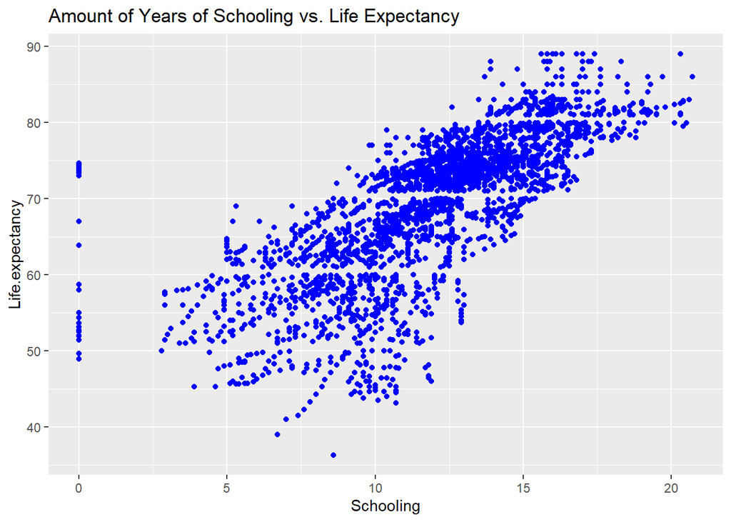

We chose to use a scatterplot to compare the number of schooling years and life expectancy across the world to showcase the correlation whether it be a negative or positive correlation. As a result of the scatterplot, you can see the x-axis being schooling and y-axis being life expectancy, and the blue dots representing the data. As one can see in the chart there is a high positive correlation between life expectancy and years of schooling throughout the world. For example for years of schooling above 10 years, the average life expectancy of a person is higher compared to years of schooling for 5 years. For each year add of schooling and gaining an education the life expectancy increases.

### Chart 2

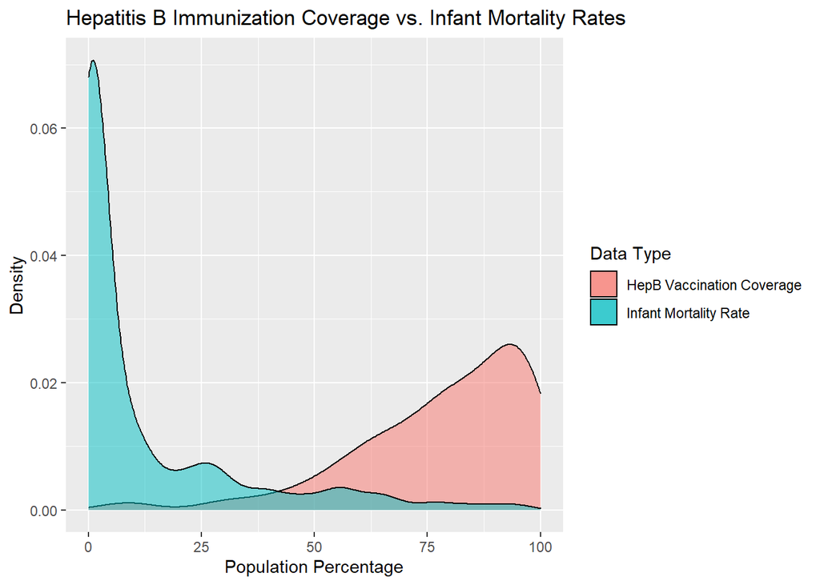

### Chart 3

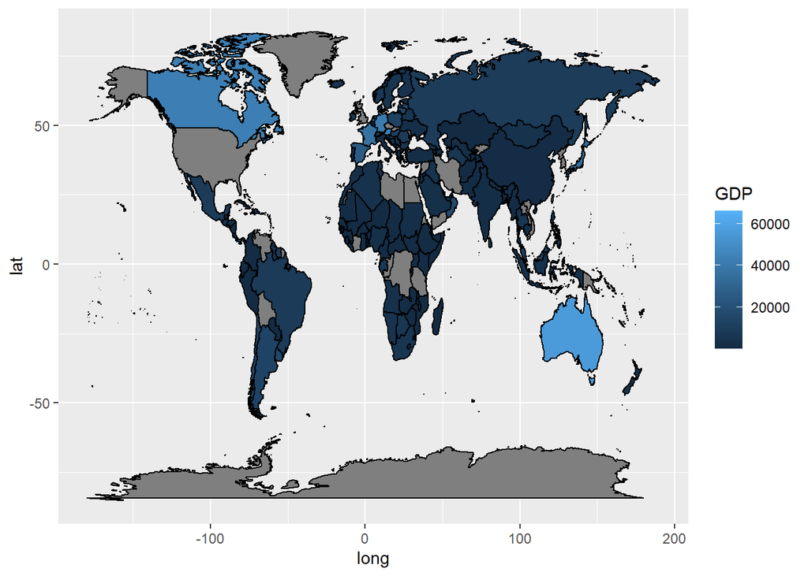

### Chart 4

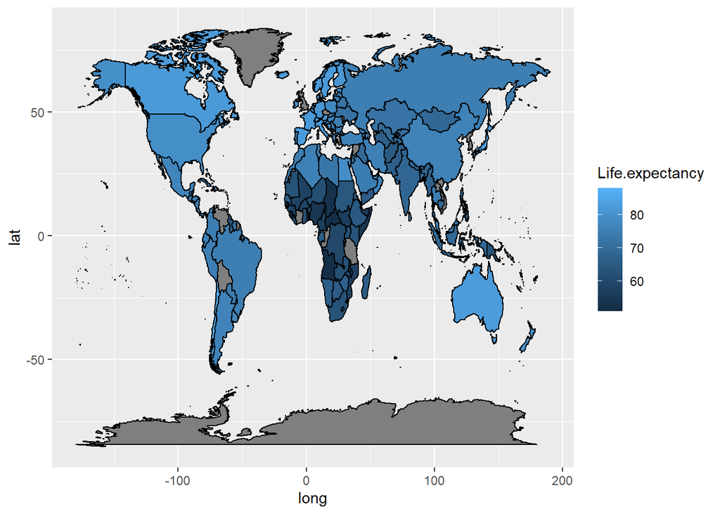

We chose to use two graphs to compare GDP against life expectancy. The first graph visualizes gross domestic product values around the world, showing a global map. Lighter blue colors represent higher GDPs and darker blue shades represents lower GDP. Our second graph is a global map of life expectancies, where lighter blue hues correlate with higher life expectancies. Our intent in using these two graphs is to display a clear visual example of the relationship between GDP and life expectancy.